# Taller 3: Datos geoespaciales, web scraping y herramientas de visualización

Taller de Programación en R · Facultad de Economía, Universidad de los Andes · 2026-2

Daniel Eduardo Ramirez Hoyos | Daniel Ricardo Valderrama | David Santiago Morales Camacho

15/11/2026

# Punto 1. Datos geoespaciales

## 1.A IDF departamental artificial

```r
# ==============================================================================
# 1.A IDF DEPARTAMENTAL ARTIFICIAL
# ==============================================================================
idf_dpto          <- readRDS(file.path(ruta_resultados, "1_A_idf_dpto.rds"))
resumen_faltantes <- readRDS(file.path(ruta_resultados, "1_A_resumen_faltantes.rds"))
base_mun          <- readRDS(file.path(ruta_app_datos, "base_mun.rds"))   # un municipio por fila

archivo_uniones <- file.path(ruta_resultados, "1_A_verificacion_uniones.xlsx")
pob_sin_idf     <- read.xlsx(archivo_uniones, sheet = "Poblacion_sin_IDF")
rango_dpto      <- read.xlsx(file.path(ruta_resultados, "1_A_idf_dpto.xlsx"), sheet = "Rango_municipal")
rango_dpto$cod_dpto <- formatC(as.integer(rango_dpto$cod_dpto), width = 2, flag = "0")   # formatC: código departamental a 2 dígitos
```

### 1.A.1 Revisión de las llaves y uniones

Tabla 1.A.1. Resultado de las uniones entre IDF (DNP), población y VA (DANE)

| Concepto | Municipios |
| --- | --- |
| Municipios en la base del IDF | 1.103 |
| Sin puntaje IDF | 0 |
| Sin población 2024 | 0 |
| Sin VA 2023 | 0 |
| Con los tres datos completos | 1.103 |

Territorios que están en población y VA, pero no en la base del IDF del DNP (no entran al cálculo). Ninguno es municipio: son áreas no municipalizadas (ANM) y la isla de San Andrés, que administra la gobernación.

Tabla 1.A.2. Territorios sin IDF municipal (20)

| Código | Territorio | Departamento | Tipo | Población 2024 |
| --- | --- | --- | --- | --- |
| 88001 | San Andrés | Archipiélago de San Andrés, Providencia y Santa Catalina | Isla administrada por la gobernación | 56.965 |
| 91263 | El Encanto (ANM) | Amazonas | Área no municipalizada | 2.211 |
| 91405 | La Chorrera (ANM) | Amazonas | Área no municipalizada | 3.127 |
| 91407 | La Pedrera (ANM) | Amazonas | Área no municipalizada | 4.073 |
| 91430 | La Victoria (ANM) | Amazonas | Área no municipalizada | 681 |
| 91460 | Miriti - Paraná (ANM) | Amazonas | Área no municipalizada | 2.043 |
| 91530 | Puerto Alegría (ANM) | Amazonas | Área no municipalizada | 793 |
| 91536 | Puerto Arica (ANM) | Amazonas | Área no municipalizada | 1.067 |
| 91669 | Puerto Santander (ANM) | Amazonas | Área no municipalizada | 1.853 |
| 91798 | Tarapacá (ANM) | Amazonas | Área no municipalizada | 4.018 |
| 94663 | Mapiripana (ANM) | Guainía | Área no municipalizada | 0 |
| 94883 | San Felipe (ANM) | Guainía | Área no municipalizada | 1.926 |
| 94884 | Puerto Colombia (ANM) | Guainía | Área no municipalizada | 1.971 |
| 94885 | La Guadalupe (ANM) | Guainía | Área no municipalizada | 319 |
| 94886 | Cacahual (ANM) | Guainía | Área no municipalizada | 902 |
| 94887 | Pana Pana (ANM) | Guainía | Área no municipalizada | 2.001 |
| 94888 | Morichal (ANM) | Guainía | Área no municipalizada | 1.052 |
| 97511 | Pacoa (ANM) | Vaupés | Área no municipalizada | 4.255 |
| 97777 | Papunahua (ANM) | Vaupés | Área no municipalizada | 768 |
| 97889 | Yavaraté (ANM) | Vaupés | Área no municipalizada | 1.086 |

Municipios con VA 2023 igual a cero (su ponderador queda en cero):

Tabla 1.A.3. Municipios con IDF y VA igual a cero

| Código | Municipio | Departamento | IDF | Población 2024 | VA 2024 |
| --- | --- | --- | --- | --- | --- |
| 27493 | Nuevo Belén de Bajirá | CHOCÓ | 54,0262 | 29.812 | 0 |

**Comentarios del grupo (llaves y municipios que no entran):**

> La Tabla 1.A.1 muestra que los 1.103 municipios de la base del IDF del DNP encontraron pareja en las bases de población 2024 y valor agregado 2023 del DANE, así que ninguno quedó sin alguno de los tres datos. La Tabla 1.A.2 hace el cruce en sentido contrario: hay 20 códigos que están en las bases del DANE pero no tienen IDF, por lo que no entran al cálculo. Ninguno corresponde a un municipio. Son 19 áreas no municipalizadas (9 de Amazonas, 7 de Guainía y 3 de Vaupés) y San Andrés, que no cuenta como municipio porque está bajo la jurisdicción directa de la gobernación. Llama la atención Mapiripana (94663), que aparece con población 0 y valor agregado 0. En la Tabla 1.A.3 vemos que Nuevo Belén de Bajirá sí tiene IDF, pero su valor agregado es 0. Por eso su ponderador es 0 y no influye en el IDF del Chocó. La razón más probable es que el municipio se creó en noviembre de 2023 y el DANE todavía no le reporta un valor agregado propio.

### 1.A.2 Proyección del valor agregado 2023 a 2024

El VA municipal del DANE (anexo `anex-PIBDep-ValorAgreMuni-2011-2024p`, Cuadro 1) está a **precios corrientes** (cuentas nacionales base 2015), en miles de millones de pesos. Se proyectó con el crecimiento del PIB nominal de Colombia en 2024, calculado con la fila COLOMBIA del anexo “PIB total por departamentos” del DANE (serie 2005-2025pr, publicada el 3 de julio de 2026; fila 11, columnas U = 2023 y V = 2024p). El anexo se descarga de la página de [Cuentas nacionales departamentales del DANE](https://www.dane.gov.co/index.php/estadisticas-por-tema-2/cuentas-nacionales/cuentas-nacionales-departamentales):

```r
round((1713316 - 1587200) / 1587200 * 100, 2)   # tasa redondeada a dos decimales
```

```
## [1] 7.95
```

```r
round((1713316 - 1587200) / 1587200 * 100, 2) == tasa_pib_2024   # debe salir TRUE
```

```
## [1] TRUE
```

VA 2024 = VA 2023 × (1 + 7,95 / 100).

**Justificación de la tasa elegida:**

> Calculamos el crecimiento del PIB de Colombia en 2024 a precios corrientes, porque el valor agregado municipal está expresado en esos mismos precios. Usamos el PIB nominal reportado por el DANE: 1.713.316 miles de millones de pesos en 2024 (dato provisional) y 1.587.200 miles de millones en 2023. Estos datos salen del Anexo PIB total por departamentos, consultado el 1 de noviembre de 2026. La tasa resultante es 7,95 %, redondeada a dos decimales como pide el enunciado, y coincide con el 7,9 % que publica el boletín de Cuentas Nacionales 2024p. Descartamos el crecimiento real porque excluye la inflación, y aplicarlo a un valor agregado en pesos corrientes lo subestimaría. Por simplicidad, digitamos las cifras a mano en el script en lugar de extraerlas de una base de datos, y el chunk p1_a_tasa comprueba la cuenta.

### 1.A.3 Ponderadores y comprobación del cálculo

Se recalcula aquí el IDF departamental desde la base municipal, por dos procedimientos, para comprobar el resultado del script.

```r
# Solo entran los municipios con IDF, población y VA
base_w <- base_mun %>%
  filter(!is.na(idf), !is.na(poblacion), !is.na(va_2024)) %>%
  group_by(cod_dpto) %>%
  mutate(w = (poblacion * va_2024) / sum(poblacion * va_2024)) %>%
  ungroup()

comprobacion <- base_w %>%
  group_by(cod_dpto, nombre_dpto) %>%
  summarise(suma_w        = sum(w),                                   # debe ser 1
            idf_suma_w    = sum(idf * w),                             # procedimiento 1: fórmula (1)
            idf_weighted  = weighted.mean(idf, poblacion * va_2024),  # procedimiento 2: weighted.mean
            .groups = "drop") %>%
  left_join(idf_dpto %>% select(cod_dpto, idf_dpto), by = "cod_dpto")

# Verificación: ponderadores suman 1 y los tres cálculos coinciden
all(abs(comprobacion$suma_w - 1) < 1e-6)
```

```
## [1] TRUE
```

```r
all(abs(comprobacion$idf_suma_w - comprobacion$idf_weighted) < 1e-6)
```

```
## [1] TRUE
```

```r
all(abs(round(comprobacion$idf_suma_w, 2) - comprobacion$idf_dpto) < 1e-6)
```

```
## [1] TRUE
```

Tabla 1.A.4. Ponderadores y cálculo comprobado por otro procedimiento

| Código | Departamento | Suma de w | IDF: Σ IDF·w | IDF: weighted.mean() | IDF municipal mínimo | IDF municipal máximo |
| --- | --- | --- | --- | --- | --- | --- |
| 05 | ANTIOQUIA | 1 | 69,5804 | 69,5804 | 34,3310 | 76,7160 |
| 08 | ATLÁNTICO | 1 | 73,0325 | 73,0325 | 33,4814 | 75,5418 |
| 11 | BOGOTÁ, D.C. | 1 | 77,0385 | 77,0385 | 77,0385 | 77,0385 |
| 13 | BOLÍVAR | 1 | 63,2839 | 63,2839 | 32,3334 | 66,3812 |
| 15 | BOYACÁ | 1 | 64,5438 | 64,5438 | 41,9228 | 81,0961 |
| 17 | CALDAS | 1 | 59,6280 | 59,6280 | 50,7595 | 63,9009 |
| 18 | CAQUETÁ | 1 | 42,1123 | 42,1123 | 39,1515 | 60,7111 |
| 19 | CAUCA | 1 | 61,7171 | 61,7171 | 41,9962 | 66,2404 |
| 20 | CESAR | 1 | 62,6444 | 62,6444 | 39,6803 | 73,6970 |
| 23 | CÓRDOBA | 1 | 64,8630 | 64,8630 | 42,0619 | 73,7402 |
| 25 | CUNDINAMARCA | 1 | 58,8801 | 58,8801 | 45,3207 | 74,3258 |
| 27 | CHOCÓ | 1 | 56,9119 | 56,9119 | 32,7546 | 74,1803 |
| 41 | HUILA | 1 | 51,8150 | 51,8150 | 45,3506 | 65,7867 |
| 44 | LA GUAJIRA | 1 | 46,8655 | 46,8655 | 30,8210 | 76,3308 |
| 47 | MAGDALENA | 1 | 60,8675 | 60,8675 | 27,4261 | 65,2562 |
| 50 | META | 1 | 60,4852 | 60,4852 | 41,4898 | 64,7420 |
| 52 | NARIÑO | 1 | 58,9172 | 58,9172 | 42,1491 | 79,9860 |
| 54 | NORTE DE SANTANDER | 1 | 59,9673 | 59,9673 | 42,7979 | 65,2629 |
| 63 | QUINDÍO | 1 | 61,6196 | 61,6196 | 42,9498 | 65,5788 |
| 66 | RISARALDA | 1 | 60,2875 | 60,2875 | 47,8546 | 62,2977 |
| 68 | SANTANDER | 1 | 62,2044 | 62,2044 | 36,8349 | 75,5002 |
| 70 | SUCRE | 1 | 53,8428 | 53,8428 | 39,5032 | 69,7950 |
| 73 | TOLIMA | 1 | 52,9152 | 52,9152 | 38,4931 | 66,9710 |
| 76 | VALLE DEL CAUCA | 1 | 58,2942 | 58,2942 | 40,5065 | 72,1329 |
| 81 | ARAUCA | 1 | 61,0719 | 61,0719 | 43,3325 | 76,2546 |
| 85 | CASANARE | 1 | 59,6820 | 59,6820 | 39,6617 | 68,7540 |
| 86 | PUTUMAYO | 1 | 54,4048 | 54,4048 | 40,9520 | 72,3097 |
| 88 | ARCHIPIÉLAGO DE SAN ANDRÉS, PROVIDENCIA Y SANTA CATALINA | 1 | 55,2313 | 55,2313 | 55,2313 | 55,2313 |
| 91 | AMAZONAS | 1 | 49,8012 | 49,8012 | 37,7341 | 50,1963 |
| 94 | GUAINÍA | 1 | 52,4696 | 52,4696 | 40,4990 | 53,1877 |
| 95 | GUAVIARE | 1 | 61,6319 | 61,6319 | 40,9463 | 62,8124 |
| 97 | VAUPÉS | 1 | 48,8308 | 48,8308 | 43,9580 | 48,8889 |
| 99 | VICHADA | 1 | 46,2285 | 46,2285 | 41,8283 | 50,9653 |

**Comentarios del grupo (verificaciones):**

> El IDF departamental se calcula como la suma del IDF de cada municipio multiplicado por su ponderador w. Para comprobar el resultado lo calculamos también con weighted.mean(). La Tabla 1.A.4 muestra que los dos valores coinciden en los 33 departamentos y que en todos los ponderadores suman 1. Además, cada IDF departamental queda entre el mínimo y el máximo de sus municipios. Una verificación adicional muestra que el IDF departamental es idéntico si se usa el valor agregado de 2023 o el proyectado a 2024. Como todos los municipios crecen a la misma tasa, el factor de crecimiento aparece en el numerador y en el denominador de w y se cancela, así que la proyección no cambia el resultado. La mayoría de los departamentos tiene mucha variación entre sus municipios: casi todos los mínimos están entre 32 y 46 y casi todos los máximos entre 62 y 81, con Boyacá (81,1) y Nariño (80,0) en el extremo superior. Las excepciones son San Andrés, porque solo Providencia y Santa Catalina es municipio, y Bogotá, que como Distrito Capital cuenta como departamento. También tienen rangos estrechos Vaupés, Vichada, Amazonas y Guainía, que tienen entre 2 y 4 municipios cada uno.

### 1.A.4 IDF departamental

Tabla 1.A.5. IDF departamental artificial, 2024 (de mayor a menor)

| Código | Departamento | IDF departamental | IDF promedio simple | Municipios | Población 2024 | VA 2024 (miles de millones) |
| --- | --- | --- | --- | --- | --- | --- |
| 11 | BOGOTÁ, D.C. | 77,04 | 77,04 | 1 | 7.918.660 | 375.940,81 |
| 08 | ATLÁNTICO | 73,03 | 57,14 | 23 | 2.836.795 | 68.638,45 |
| 05 | ANTIOQUIA | 69,58 | 54,81 | 125 | 6.880.799 | 226.264,72 |
| 23 | CÓRDOBA | 64,86 | 58,49 | 30 | 1.969.108 | 28.580,80 |
| 15 | BOYACÁ | 64,54 | 57,61 | 123 | 1.283.225 | 42.199,61 |
| 13 | BOLÍVAR | 63,28 | 53,61 | 46 | 2.227.181 | 54.393,68 |
| 20 | CESAR | 62,64 | 57,32 | 25 | 1.440.484 | 36.818,02 |
| 68 | SANTANDER | 62,20 | 56,57 | 87 | 2.380.650 | 91.640,00 |
| 19 | CAUCA | 61,72 | 51,42 | 42 | 1.583.095 | 27.896,03 |
| 95 | GUAVIARE | 61,63 | 52,14 | 4 | 84.550 | 1.321,68 |
| 63 | QUINDÍO | 61,62 | 54,43 | 12 | 556.880 | 13.527,34 |
| 81 | ARAUCA | 61,07 | 59,49 | 7 | 277.883 | 9.185,24 |
| 47 | MAGDALENA | 60,87 | 52,38 | 30 | 1.526.269 | 22.542,83 |
| 50 | META | 60,49 | 56,20 | 29 | 1.144.286 | 55.933,07 |
| 66 | RISARALDA | 60,29 | 54,41 | 14 | 997.930 | 25.826,84 |
| 54 | NORTE DE SANTANDER | 59,97 | 54,65 | 40 | 1.694.970 | 25.814,80 |
| 85 | CASANARE | 59,68 | 58,32 | 19 | 467.565 | 23.987,97 |
| 17 | CALDAS | 59,63 | 57,75 | 27 | 1.050.126 | 26.083,15 |
| 52 | NARIÑO | 58,92 | 57,06 | 64 | 1.704.383 | 24.064,52 |
| 25 | CUNDINAMARCA | 58,88 | 58,70 | 116 | 3.463.004 | 96.793,89 |
| 76 | VALLE DEL CAUCA | 58,29 | 55,20 | 42 | 4.693.432 | 148.809,28 |
| 27 | CHOCÓ | 56,91 | 56,65 | 31 | 586.128 | 7.179,02 |
| 88 | ARCHIPIÉLAGO DE SAN ANDRÉS, PROVIDENCIA Y SANTA CATALINA | 55,23 | 55,23 | 1 | 6.285 | 243,44 |
| 86 | PUTUMAYO | 54,40 | 56,40 | 13 | 385.400 | 6.051,30 |
| 70 | SUCRE | 53,84 | 52,51 | 26 | 1.019.575 | 12.939,74 |
| 73 | TOLIMA | 52,92 | 52,98 | 47 | 1.380.444 | 33.754,80 |
| 94 | GUAINÍA | 52,47 | 46,84 | 2 | 50.069 | 512,45 |
| 41 | HUILA | 51,82 | 54,89 | 37 | 1.194.754 | 26.844,06 |
| 91 | AMAZONAS | 49,80 | 43,97 | 2 | 64.243 | 1.097,47 |
| 97 | VAUPÉS | 48,83 | 46,71 | 3 | 37.666 | 413,29 |
| 44 | LA GUAJIRA | 46,87 | 56,87 | 15 | 1.047.859 | 21.411,93 |
| 99 | VICHADA | 46,23 | 46,22 | 4 | 143.117 | 1.123,14 |
| 18 | CAQUETÁ | 42,11 | 55,18 | 16 | 425.827 | 6.341,20 |

El IDF se calculó para 33 departamentos. El más alto es BOGOTÁ, D.C. (77,04) y el más bajo es CAQUETÁ (42,11).

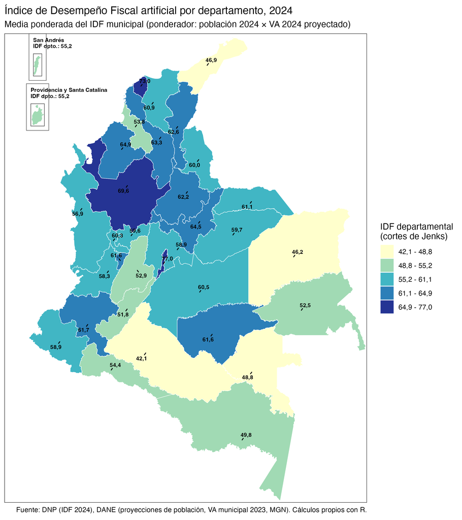

### Análisis 1.A

> Los departamentos con mayor IDF son Bogotá (77,0), Atlántico (73,0) y Antioquia (69,6), y los de menor IDF son Caquetá (42,1), Vichada (46,2) y La Guajira (46,9). Como referencia usamos la media nacional, es decir, el promedio de los IDF de los 33 departamentos. En la región Andina la mayoría está por encima de la media nacional, salvo Huila y Tolima, y en el Caribe pasa lo mismo, salvo La Guajira y Sucre. La región Pacífica está dividida: Chocó y Valle del Cauca quedan por debajo, y Cauca y Nariño por encima. En la Orinoquía solo Vichada está por debajo, mientras que en la Amazonía todos lo están menos Guaviare. San Andrés, Providencia y Santa Catalina (55,2) también queda por debajo, aunque su cálculo solo incluye a Providencia y Santa Catalina. La ponderación ayuda a explicar este ranking. El ponderador combina población y valor agregado, así que los municipios más grandes pesan mucho más que los pequeños. Por eso el IDF departamental puede alejarse bastante del promedio simple de sus municipios: Atlántico pasa de 57,1 a 73,0 y Antioquia de 54,8 a 69,6, mientras Caquetá baja de 55,2 a 42,1 y La Guajira de 56,9 a 46,9. En los dos primeros, los municipios de mayor peso tienen un IDF más alto que el resto del departamento. En los dos últimos ocurre lo contrario.

## 1.B Mapa del IDF municipal

```r
# ==============================================================================
# 1.B MAPA MUNICIPAL: DIAGNÓSTICO
# ==============================================================================
diagnostico_1b <- readRDS(file.path(ruta_resultados, "1_B_diagnostico.rds"))

# Geometrías inválidas en cada paso (BLOQUE 8 del Punto 1)
n_inv_original <- diagnostico_1b$original[diagnostico_1b$medida == "Geometrías inválidas"]
n_inv_simple   <- diagnostico_1b$simplificado[diagnostico_1b$medida == "Geometrías inválidas"]
n_inv_final    <- diagnostico_1b$simplificado[diagnostico_1b$medida == "Geometrías inválidas después de corregir"]

# Enteros sin decimales y el resto con un decimal (la columna mezcla conteos y segundos)
formato_1b <- function(x) {
  ifelse(is.na(x), "",
         ifelse(x == round(x),
                formatC(x, format = "d", big.mark = "."),                         # formatC: conteos con punto de miles
                formatC(x, format = "f", digits = 1, decimal.mark = ",")))        # formatC: un decimal con coma
}
```

El shapefile municipal del DANE se trabajó en tres pasos: (1) se leyó el original, (2) se simplificó con `st_simplify()` para quitar vértices y (3) se corrigieron con `st_make_valid()` las geometrías que se dañaron al simplificar. El mapa se dibuja con el resultado del paso 3.

### 1.B.1 Geometrías inválidas en cada paso

Tabla 1.B.1. Geometrías inválidas en cada paso

| Paso | Geometrías inválidas |
| --- | --- |
| 1. Shapefile original del DANE | 0 |
| 2. Después de simplificar con st_simplify() | 0 |
| 3. Después de corregir con st_make_valid() (versión que se usa en el mapa) | 0 |

El shapefile original tenía 0 geometrías inválidas, después de simplificar quedaron 0 y después de corregir, 0: el mapa municipal se dibuja con geometrías válidas. Si alguna geometría resultara inválida, el BLOQUE 8 del Punto 1 imprime en la consola el código del municipio y la causa (`st_is_valid(..., reason = TRUE)`).

### 1.B.2 Shapefile original frente a la versión final

Tabla 1.B.2. Tamaño y tiempos del shapefile municipal (vacío: no aplica al original)

| Medida | Shapefile original | Simplificado y corregido (mapa) |
| --- | --- | --- |
| Polígonos | 1.122 | 1.122 |
| Vértices | 6.212.672 | 60.088 |
| Tamaño en memoria (Mb) | 95,6 | 1,8 |
| Segundos para dibujar | 32,2 | 0,4 |
| Segundos para simplificar |  | 91,2 |
| Segundos para exportar el mapa final |  | 1,2 |

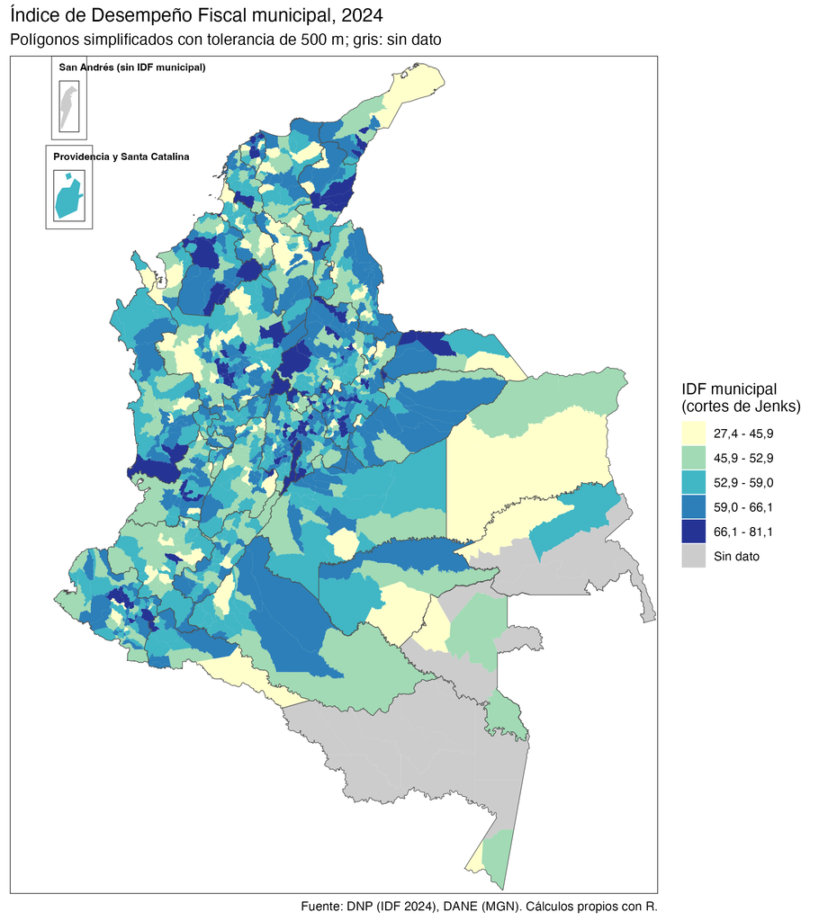

# Punto 2. Web scraping y API

## 2.A IBR overnight (web scraping, Banco de la República)

```r
# ==============================================================================
# 2.A IBR OVERNIGHT DIARIA
# ==============================================================================
ibr_on       <- readRDS(file.path(ruta_app_datos, "ibr_on.rds"))
registro_ibr <- read.xlsx(file.path(ruta_resultados, "2_A_ibr_on.xlsx"), sheet = "Registro")
```

Tabla 2.A.1. Registro de la extracción: fuente, serie, método, fecha de consulta, unidad y convención

|  | IBR overnight |
| --- | --- |
| fuente | Banco de la República, SUAMECA (serie 241) |
| serie | Indicador Bancario de Referencia (IBR) overnight, nominal |
| metodo | Web scraping dinámico (chromote, botón ‘Vista tabla’) |
| url | https://suameca.banrep.gov.co/estadisticas-economicas/informacionSerie/241/tasas_interes_indicador_bancario_referencia_ibr |
| fecha_consulta | 15/11/2026 11:35 |
| unidad | Porcentaje (%) nominal anual |
| convencion | Tasa nominal anual, base 360: días calendario sobre un año de 360 días (Reglamento del IBR, art. 34); el BanRep publica además la tasa efectiva |
| n_obs | 1426 |
| fecha_min | 02/01/2020 |
| fecha_max | 31/10/2025 |

La serie tiene 1426 días hábiles con dato entre el 02/01/2020 y el 31/10/2025.

Tabla 2.A.2. Observaciones contrastadas con la página de SUAMECA

| Fecha | IBR ON extraída (%) | IBR ON en la página de SUAMECA (%) | ¿Coincide? |
| --- | --- | --- | --- |
| 2020-01-02 | 4,114 | 4,114 | Sí |
| 2023-06-30 | 12,270 | 12,270 | Sí |
| 2025-10-31 | 8,730 | 8,730 | Sí |

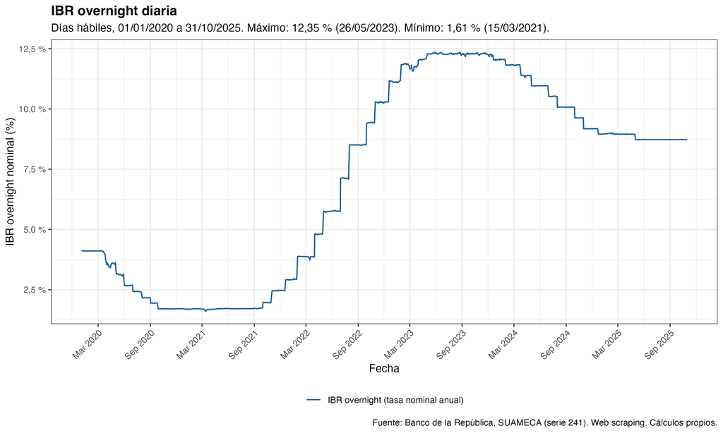

## 2.B SOFR overnight (API, Fed de Nueva York)

```r
# ==============================================================================
# 2.B SOFR OVERNIGHT DIARIA
# ==============================================================================
sofr_on       <- readRDS(file.path(ruta_app_datos, "sofr_on.rds"))
registro_sofr <- read.xlsx(file.path(ruta_resultados, "2_B_sofr_on.xlsx"), sheet = "Registro")
```

Tabla 2.B.1. Registro de la extracción: fuente, serie, método, fecha de consulta, unidad y convención

|  | SOFR overnight |
| --- | --- |
| fuente | Federal Reserve Bank of New York, Markets Data API |
| serie | SOFR (Secured Overnight Financing Rate) |
| metodo | API (GET + JSON) |
| url | https://markets.newyorkfed.org/api/rates/secured/sofr/search.json?startDate=2020-01-01&endDate=2025-10-31 |
| fecha_consulta | 15/11/2026 11:35 |
| unidad | Porcentaje anual |
| convencion | Actual/360 (días calendario reales sobre un año de 360 días); mediana ponderada por volumen (percentil 50) de repos overnight con garantía de Tesoros de EE. UU., redondeada al punto básico |
| n_obs | 1458 |
| fecha_min | 02/01/2020 |
| fecha_max | 31/10/2025 |

La serie tiene 1458 días hábiles con dato entre el 02/01/2020 y el 31/10/2025.

Tabla 2.B.2. Observaciones contrastadas con la página de la Fed de Nueva York

| Fecha | SOFR ON extraída (%) | SOFR ON en la página de la Fed (%) | ¿Coincide? |
| --- | --- | --- | --- |
| 2020-01-02 | 1,54 | 1,54 | Sí |
| 2023-06-30 | 5,09 | 5,09 | Sí |
| 2025-10-31 | 4,22 | 4,22 | Sí |

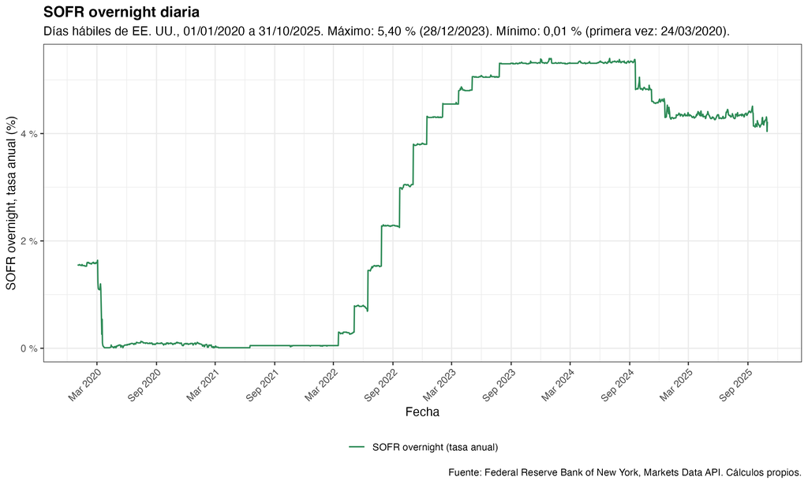

## 2.C Gráfico de doble eje

```r
# ==============================================================================
# 2.C FECHAS SIN OBSERVACIÓN, PROMEDIOS MENSUALES Y DOBLE EJE
# ==============================================================================
tasas_mensual <- readRDS(file.path(ruta_app_datos, "tasas_mensual.rds"))

# Calendario con todos los días del periodo (Clase 8) y las dos tasas
calendario <- data.frame(fecha = seq(fecha_inicio, fecha_fin, by = "day")) %>%
  left_join(ibr_on,  by = "fecha") %>%
  left_join(sofr_on, by = "fecha")

nrow(calendario)   # días del periodo
```

```
## [1] 2131
```

### Fechas sin observación

Tabla 2.C.1. Días con y sin observación de cada tasa, 01/01/2020 a 31/10/2025

| Situación | Días |
| --- | --- |
| Días del periodo | 2.131 |
| Con IBR y con SOFR | 1.384 |
| Con IBR, sin SOFR (festivos de EE. UU. hábiles en Colombia) | 42 |
| Con SOFR, sin IBR (festivos de Colombia hábiles en EE. UU.) | 74 |
| Sin ninguna tasa (fines de semana y festivos comunes) | 631 |

### Agregación mensual

Cada tasa se promedió por mes sobre sus propios días hábiles: 70 meses, entre 18 y 23 días por mes para la IBR y entre 19 y 23 para la SOFR.

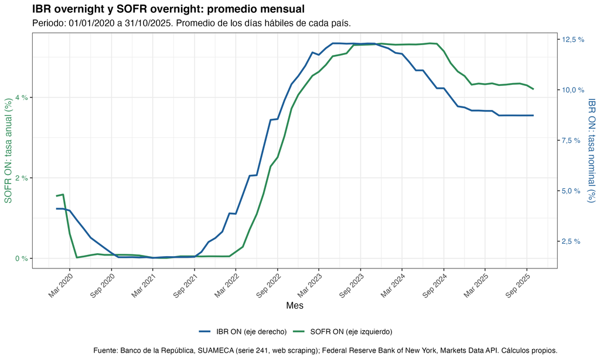

**Frecuencia elegida y tratamiento de las fechas sin observación:**

> *Las dos tasas solo se publican en días hábiles, y cada país tiene su propio calendario de festivos. Para ver cuántos días faltan armamos un calendario con los 2.131 días del periodo y le unimos las dos series. La Tabla 2.C.1 muestra que solo 1.384 días tienen las dos tasas. En 42 días hay IBR pero no SOFR, que son festivos de EE. UU. hábiles en Colombia. En 74 días hay SOFR pero no IBR, que son festivos colombianos hábiles en EE. UU. Los otros 631 días son fines de semana o festivos comunes. No imputamos ningún dato. Tampoco repetimos el último valor disponible ni interpolamos, porque eso inventaría tasas para días en que no hubo mercado. En las gráficas diarias cada serie usa solo sus días hábiles, y la línea une un día hábil con el siguiente. Para la gráfica de doble eje elegimos frecuencia mensual. Cada tasa se promedia sobre sus propios días hábiles del mes, que son entre 18 y 23 para la IBR y entre 19 y 23 para la SOFR. Así los festivos de un país no obligan a botar datos del otro, y las dos series quedan en las mismas 70 fechas. El promedio mensual también suaviza los saltos de un día de la SOFR, como los de fin de mes, que en la serie diaria no dejan ver bien la tendencia. Los días en que falta una de las dos tasas siguen como NA en la base diaria, y la app del punto 3.B los avisa.*

### Insumos para comparar las tendencias

Tabla 2.C.2. Promedio anual de los días hábiles de cada tasa (2025: enero a octubre)

| Año | IBR ON promedio (%) | SOFR ON promedio (%) | IBR − SOFR (p. p.) |
| --- | --- | --- | --- |
| 2020 | 2,77 | 0,36 | 2,41 |
| 2021 | 1,87 | 0,04 | 1,83 |
| 2022 | 6,81 | 1,64 | 5,17 |
| 2023 | 12,08 | 5,01 | 7,07 |
| 2024 | 10,63 | 5,15 | 5,48 |
| 2025 | 8,82 | 4,31 | 4,51 |

Tabla 2.C.3. Inicio, extremos y final de cada serie diaria

| Tasa | Primer dato (%) | Mínimo (%) | Fecha del mínimo (primera vez) | Máximo (%) | Fecha del máximo | Último dato (%) |
| --- | --- | --- | --- | --- | --- | --- |
| IBR ON | 4,114 | 1,614 | 15/03/2021 | 12,353 | 26/05/2023 | 8,73 |
| SOFR ON | 1,540 | 0,010 | 24/03/2020 | 5,400 | 28/12/2023 | 4,22 |

### Análisis 2.C: comparación de tendencias

> *Las dos tasas siguen el mismo ciclo, pero con diferencias de momento y de nivel. En 2020 ambas caen por la respuesta de los bancos centrales a la pandemia. La SOFR baja casi de inmediato, de 1,54 % a 0,01 % el 24 de marzo de 2020, y la IBR baja de forma más gradual, de 4,11 % hasta su mínimo de 1,61 % en marzo de 2021. Las dos se quedan en ese piso durante 2021. La IBR empieza a subir en octubre de 2021, unos cinco meses antes que la SOFR, que sube desde marzo de 2022. La subida de la IBR también es mucho más grande: llega a 12,35 % en mayo de 2023, mientras que la SOFR llega a 5,40 % a finales de 2023. Las dos se quedan en el máximo durante buena parte de 2023, y la IBR vuelve a moverse primero. Baja desde finales de 2023 hasta 8,73 % a mediados de 2025, mientras que la SOFR empieza a bajar en septiembre de 2024 y termina en 4,22 %. La Tabla 2.C.2 muestra que la diferencia entre las dos tasas cambia mucho en el periodo. Pasa de 1,83 p. p. en 2021 a 7,07 p. p. en 2023 y baja a 4,51 p. p. en 2025. Es decir, se abrió cuando el BanRep subió más fuerte que la Fed y se cerró cuando empezó a recortar antes. Hay que tener en cuenta que las dos tasas no se miden igual: la IBR se calcula con base 360 y la SOFR con Actual/360, y la gráfica de doble eje usa escalas distintas para cada una. Por eso la gráfica sirve para comparar tendencias y no niveles; para los niveles está la Tabla 2.C.2. En la serie diaria también se ve que la IBR se mueve en escalones, porque sigue de cerca la tasa de política del BanRep, mientras que la SOFR tiene más ruido de un día a otro.*

# Punto 3. Aplicativo Shiny

El aplicativo está en `app_shiny/app.R` y lee sus datos de `app_shiny/datos/`. Se abre con el botón *Run App* de RStudio (con `app.R` abierto) o con la línea de `runApp()` al final de `Taller3.R`.

## 3.A Mapa interactivo del IDF departamental

En la app se distingue el IDF departamental (índice ponderado del mapa) del IDF municipal (el de cada municipio del top 3). Esta es la tabla que la app muestra al elegir cada departamento:

Tabla 3.A. Top 3 de municipios por IDF municipal en cada departamento

| Departamento | IDF departamental | Puesto | Municipio | IDF municipal |
| --- | --- | --- | --- | --- |
| BOGOTÁ, D.C. | 77,04 | 1 | Bogotá, D.C. | 77,04 |
| ATLÁNTICO | 73,03 | 1 | Barranquilla | 75,54 |
| ATLÁNTICO | 73,03 | 2 | Usiacurí | 71,60 |
| ATLÁNTICO | 73,03 | 3 | Tubará | 71,21 |
| ANTIOQUIA | 69,58 | 1 | San Jerónimo | 76,72 |
| ANTIOQUIA | 69,58 | 2 | Copacabana | 75,34 |
| ANTIOQUIA | 69,58 | 3 | Itagüí | 75,05 |
| CÓRDOBA | 64,86 | 1 | Los Córdobas | 73,74 |
| CÓRDOBA | 64,86 | 2 | Cereté | 70,76 |
| CÓRDOBA | 64,86 | 3 | Puerto Libertador | 66,97 |
| BOYACÁ | 64,54 | 1 | Samacá | 81,10 |
| BOYACÁ | 64,54 | 2 | Sogamoso | 75,72 |
| BOYACÁ | 64,54 | 3 | Tuta | 73,11 |
| BOLÍVAR | 63,28 | 1 | El Carmen De Bolívar | 66,38 |
| BOLÍVAR | 63,28 | 2 | Soplaviento | 65,96 |
| BOLÍVAR | 63,28 | 3 | Turbaco | 65,09 |
| CESAR | 62,64 | 1 | El Paso | 73,70 |
| CESAR | 62,64 | 2 | La Jagua De Ibirico | 73,55 |
| CESAR | 62,64 | 3 | Becerrill | 73,30 |
| SANTANDER | 62,20 | 1 | Cimitarra | 75,50 |
| SANTANDER | 62,20 | 2 | Betulia | 71,63 |
| SANTANDER | 62,20 | 3 | Florián | 70,41 |
| CAUCA | 61,72 | 1 | Popayán | 66,24 |
| CAUCA | 61,72 | 2 | Guachené | 64,51 |
| CAUCA | 61,72 | 3 | Piamonte | 61,49 |
| GUAVIARE | 61,63 | 1 | San José Del Guaviare | 62,81 |
| GUAVIARE | 61,63 | 2 | Calamar | 57,04 |
| GUAVIARE | 61,63 | 3 | El Retorno | 47,76 |
| QUINDÍO | 61,62 | 1 | Circasia | 65,58 |
| QUINDÍO | 61,62 | 2 | Armenia | 62,23 |

[output cut: 63 more lines]

**Comentarios del grupo:**

> En esta pestaña se presenta un mapa interactivo que presenta el IDF departamental ponderado de 2024, al hacer clic sobre cualquier departamento o seleccionarlo en la lista desplegable (necesario para consultar el Archipiélago de San Andrés, Providencia y Santa Catalina), la aplicación resalta el departamento seleccionado, actualiza el indicador superior con su índice departamental ponderado y filtra la tabla lateral con el top 3 de municipios según su IDF municipal individual oficial del DNP. Importante notar que este grafico funciona como un mapa de calor, mostrando aquellos departamentos que tienen mejor puntaje por medio de colores (azul oscuro), sin embargo como se explica en la nota del 3C, los resultados deben ser analizados con cuidado, dado que al ser ponderado por VA y Poblacion, los resultados departamentales tienden a acercarse a los resultados de los municipios muy grandes en comparación.

## 3.B Doble eje interactivo y devaluación implícita

La app calcula π = (1 + i<sub>d</sub>) / (1 + i<sub>e</sub>) − 1, con i<sub>d</sub> = IBR ON e i<sub>e</sub> = SOFR ON en decimales. Ejemplos con las fechas contrastadas y con días en que falta una de las tasas:

Tabla 3.B. Devaluación implícita en fechas de ejemplo (NA: falta una tasa; la app lo avisa)

| Fecha | IBR ON (decimal) | SOFR ON (decimal) | Devaluación implícita (% anual) |
| --- | --- | --- | --- |
| 2020-01-02 | 0,04114 | 0,0154 | 2,53496 |
| 2020-01-06 | NA | 0,0155 | NA |
| 2020-01-20 | 0,04105 | NA | NA |
| 2023-06-30 | 0,12270 | 0,0509 | 6,83224 |
| 2025-10-31 | 0,08730 | 0,0422 | 4,32738 |

**Comentarios del grupo (instrucciones de uso, unidad del resultado, fechas sin tasa):**

## 3.C Gráfica libre

**Datos usados y qué se busca mostrar:**

> Para la visualización libre se integraron las bases municipales consolidadas en el Punto 1: el Índice de Desempeño Fiscal (IDF) municipal 2024 publicado por el DNP (puntaje de 0 a 100), las proyecciones de población municipal para 2024 del DANE (en personas) y el Valor Agregado (VA) municipal del DANE de 2023 proyectado a 2024 con el crecimiento nominal del PIB nacional (en miles de millones de pesos corrientes). El diagrama de dispersión interactivo relaciona en el eje vertical el IDF municipal frente al tamaño poblacional o económico del municipio en el eje horizontal (intercambiable mediante selector), permitiendo filtrar por uno o varios departamentos, activar escala logarítmica en el eje horizontal para distinguir municipios de distinta magnitud frente a la asimetría de las grandes capitales y superponer una recta de tendencia lineal junto con el coeficiente de correlación de Pearson dinámico.

> El objetivo analítico de esta gráfica es evaluar si el tamaño poblacional o económico de un municipio explica por sí solo su desempeño fiscal, así como ilustrar una precaución metodológica clave del Punto 1.A: dado que el IDF departamental se pondera por población y valor agregado, su valor tiende a reflejar principalmente el comportamiento de los municipios más grandes y con mayor actividad económica dentro de cada departamento, aun cuando la correlación lineal entre tamaño y desempeño fiscal municipal sea moderada o requiera otras variables adicionales para explicarse por completo (como institucionales).

# Anexo. Paquetes y funciones no vistos en clase

En `Taller3.R` y en `app_shiny/app.R` lo no visto en clase se marca así:

- **Paquete no visto:** se nombra en la configuración inicial del script y cada línea que lo usa termina en `# [NO VISTO EN CLASE]`. El único es `readxl` (`readxl::read_excel()`), que lee el Excel del IDF del DNP porque `openxlsx` no lo puede abrir.
- **Función no vista de un paquete que sí se vio:** la línea lleva el comentario `# Función no vista: ...`, con para qué sirve.
- **`formatC()` y `sprintf()`** (base R, formato de números y de texto): llevan el comentario `formatC: ...` o `sprintf: ...` en la línea donde se usan.